# Association Between Socioeconomic Factors and Iron Deficiency Anemia

Sierra Winter

2023-05-03

## Introduction

Iron deficiency is the most common micronutrient deficiency in the world, and it is the primary cause of anemia worldwide (Thurnham, 2014; Wander et al., 2017). The World Health Organization (WHO) estimates that worldwide about 42% of children less than five years old are anemic (WHO, 2017). Iron deficiency anemia is the most common form of anemia, and it is “caused by inadequate intake of iron, chronic blood loss, or a combination of both” (Rempel et al., 2021). Symptoms of anemia include weakness, shortness of breath, dizziness, and fatigue (WHO, 2017). Other effects of iron deficiency include an increased susceptibility to infection (Ekiz et al., 2004), impaired growth, reproductive function, and immune function (Denic & Agarwal, 2007), and compromised motor, neurophysiological and cognitive development (Lozoff, 2007). In one study, Lozoff (2007) used rodent models and found that myelination was disrupted in rodents with early iron deficiency anemia. Given the widespread prevalence of iron deficiency anemia and its serious health outcomes, micronutrient deficiencies are an important topic in public health research.

According to Chandran and Kirby (2021), malnutrition and anemia is prevalent in all of India. Houghton and colleagues (2019) state that “anemia prevalence estimates are nearly 60% in children younger than five years.” In the state of Madhya Pradesh, India, Chandran and Kirby (2021) found that there was a higher likelihood of childhood anemia associated with mother’s who were less educated, younger, and belonged to a scheduled tribe. Another study by Yang and colleagues (2018) found that anemia was most prevalent in countries with the lowest socioeconomic status. Other studies have found that there is an association between the hemoglobin levels of a child and the socioeconomic status of a family (Onyeneho et al., 2019). Low nutritional iron consumption due to food insecurity also plays a role in the iron status of children. Additionally, a study on children 6-59 months old in Namibia showed that there was an increased risk of anemia for children in poorer households than in richer households (Shimanda et al., 2020). These studies indicate that lower socioeconomic status and the resultant lack of nutritional iron consumption can be a leading cause of iron deficiency anemia.

Iron deficiency anemia can be diagnosed by measuring certain protein levels in blood. The Institute of Medicine (1993) uses a hemoglobin concentration of less than 11.0 grams per deciliter (g/dL) to define anemia in infants and children younger than six years old. Soluble transferrin receptor (sTfR) is used for characterizing Iron deficiency. According to Wander and colleagues (2017), transferrin is an iron ‘chaperone’ molecule that is more robust to inflammation than ferritin. Although sTfR in serum can be elevated because it is related to erythropoiesis, a sTfR test is often used to differentiate “between anemia caused by iron deficiency and anemia caused by chronic disease or inflammation” (Kundrapu & Noguez, 2018). Depletion of iron is defined as serum ferritin less than 12 ng/ml (Wang et al., 2010). However, serum ferritin is an acute phase reactant (Wang et al., 2010). Inflammation or infection anywhere in the body can increase ferritin levels, making it unreliable for measuring iron deficiency when an individual is experiencing inflammation.

As iron deficiency anemia can be caused by inadequate dietary iron consumption (Aspuru et al., 2011), socioeconomic factors may play a role in contributing to the prevalence of iron deficiency anemia. With the high estimated prevalence of anemia in children under five years old in India, analysis of possible socioeconomic predictors of iron deficiency anemia was performed using the *Multiple-micronutrient status of Indian children* dataset (McIntosh et al., 2019). The association between the families’ wealth index and the education level of the mother and the binary outcome of iron deficiency anemia status of their children was assessed using logistic regression models.

### Dataset Description

The dataset was collected from a convenience sample of 120 children in India. Their ages range from 12 to 23 months. Human sera samples were collected from 77 participants, and a subset of 75 participants were used in these analyses. The variables that were used from the dataset were the mother’s education level, wealth index, sex of the child, age of the child (months), and hemoglobin (Hb) (g/dL). Iron deficiency anemia is defined as hemoglobin (Hb) less than 11.0 g/dl (UpToDate, Inc., 2023). Using this cutoff (Hb < 11.0 g/dl), there were 61 anemic individuals, and 14 individuals who were *not* anemic (view Table 1).

```r
library(tidyverse)
```

```r
library(ggplot2)
library(dplyr)
library(car)
library(table1)
iad <- read.csv("iadata.csv")
iad <- iad

ida2 <- iad %>%
  mutate(hb.bin = ifelse(hb_gdL > 11, "0", "1"))
```

#### Table 1. Summary Statistics for Wealth Index and Mother’s Education Level

```r
ida2 <- ida2 %>%
  mutate(AnemiaStatus = ifelse(hb.bin == "0", "Not Anemic", "Anemic")) %>%
  mutate(motheredu = str_to_sentence(motheredu)) %>%
  mutate(sex = str_to_sentence(sex))
label(ida2$motheredu) <- "Mother's Education Level"
label(ida2$wealthindex) <- "Wealth Index"
label(ida2$sex) <- "Sex"
label(ida2$childagemo) <- "Age (Months)"
table1(~ wealthindex + motheredu + sex + childagemo | AnemiaStatus, data = ida2)
```

|  | Anemic (N=61) | Not Anemic (N=14) | Overall (N=75) |
| --- | --- | --- | --- |
| Wealth Index |  |  |  |
| Mean (SD) | -0.0280 (2.26) | 0.216 (2.91) | 0.0176 (2.38) |
| Median [Min, Max] | -0.592 [-3.86, 4.83] | 0.822 [-3.63, 4.04] | -0.475 [-3.86, 4.83] |
| Mother's Education Level |  |  |  |
| Did not study | 11 (18.0%) | 3 (21.4%) | 14 (18.7%) |
| Primary | 9 (14.8%) | 1 (7.1%) | 10 (13.3%) |
| Secondary | 33 (54.1%) | 6 (42.9%) | 39 (52.0%) |
| University | 8 (13.1%) | 4 (28.6%) | 12 (16.0%) |
| Sex |  |  |  |
| Female | 24 (39.3%) | 9 (64.3%) | 33 (44.0%) |
| Male | 37 (60.7%) | 5 (35.7%) | 42 (56.0%) |
| Age (Months) |  |  |  |
| Mean (SD) | 17.4 (3.71) | 17.0 (3.46) | 17.3 (3.65) |
| Median [Min, Max] | 16.7 [12.1, 23.9] | 15.8 [12.5, 22.9] | 16.5 [12.1, 23.9] |

## Research Question 1

Is there an association between a families’ wealth index and the iron deficiency anemia status of their child?

H<sub>0</sub>: There is no association between the iron deficiency anemia status of children and wealth index.

H<sub>1</sub>: There is an association between the iron deficiency anemia status of children and wealth index.

#### Table 2. Research Question 1 Summary Statistics

```r
ida2 <- ida2 %>%
  mutate(AnemiaStatus = ifelse(hb.bin == "0", "Not Anemic", "Anemic")) %>%
  mutate(sex = str_to_sentence(sex))
label(ida2$wealthindex) <- "Wealth Index"
label(ida2$sex) <- "Sex"
label(ida2$childagemo) <- "Age (Months)"
table1(~ wealthindex + sex + childagemo | AnemiaStatus, data = ida2)
```

|  | Anemic (N=61) | Not Anemic (N=14) | Overall (N=75) |
| --- | --- | --- | --- |
| Wealth Index |  |  |  |
| Mean (SD) | -0.0280 (2.26) | 0.216 (2.91) | 0.0176 (2.38) |
| Median [Min, Max] | -0.592 [-3.86, 4.83] | 0.822 [-3.63, 4.04] | -0.475 [-3.86, 4.83] |
| Sex |  |  |  |
| Female | 24 (39.3%) | 9 (64.3%) | 33 (44.0%) |
| Male | 37 (60.7%) | 5 (35.7%) | 42 (56.0%) |
| Age (Months) |  |  |  |
| Mean (SD) | 17.4 (3.71) | 17.0 (3.46) | 17.3 (3.65) |
| Median [Min, Max] | 16.7 [12.1, 23.9] | 15.8 [12.5, 22.9] | 16.5 [12.1, 23.9] |

### Statistical Analysis

A logistic regression was performed using a binary outcome of iron deficiency anemia status and predictor variables: wealth index, sex of the child, and age of the child.

Independence of observations was assessed visually. Each participant is independently observed.

### Data Visualization of Iron Deficiency Anemia Status and Wealth Index

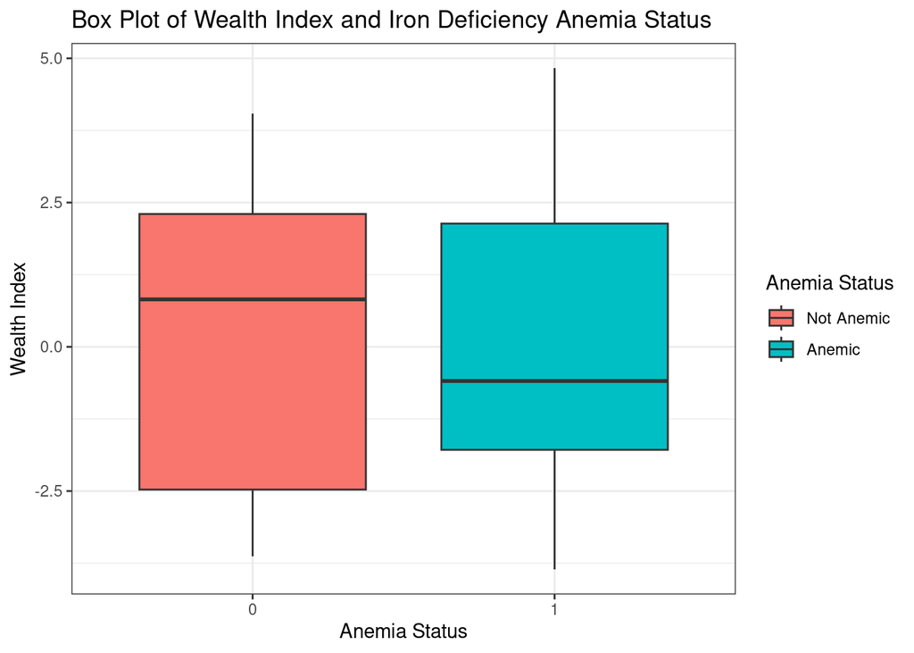

```r
ggplot(ida2, aes(x = hb.bin, y = wealthindex, fill = hb.bin))+
  geom_boxplot()+
  labs(title = "Box Plot of Wealth Index and Iron Deficiency Anemia Status")+
  scale_fill_discrete(name = "Anemia Status", labels = c("Not Anemic", "Anemic"))+
  ylab("Wealth Index")+
  xlab("Anemia Status")+
  theme_bw()
```

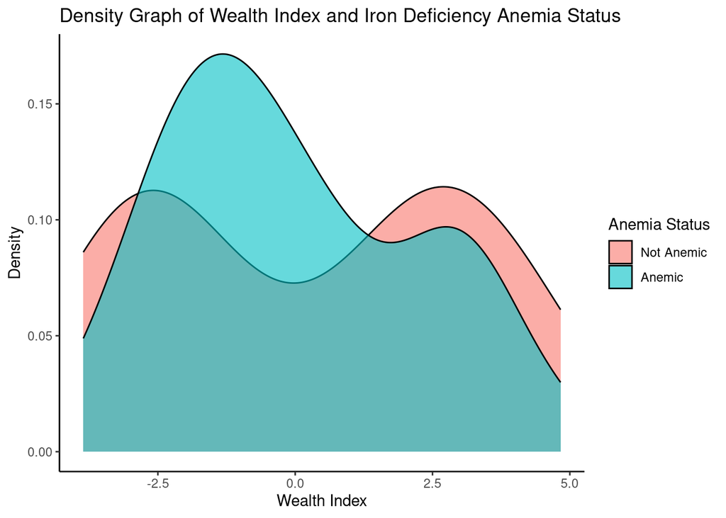

```r
ggplot(ida2, aes(fill = factor(hb.bin), x = wealthindex))+
  geom_density(alpha = 0.6)+
  labs(title = "Density Graph of Wealth Index and Iron Deficiency Anemia Status")+
  scale_fill_discrete(name = "Anemia Status", labels = c("Not Anemic", "Anemic"))+
  ylab("Density")+
  xlab("Wealth Index")+
  theme_classic()
```

### Research Question 1 Logistic Regression

```r
fit1 <- glm(factor(hb.bin) ~ wealthindex + factor(sex) + childagemo, family = binomial, data = ida2)

summary(fit1)
```

```
##
## Call:
## glm(formula = factor(hb.bin) ~ wealthindex + factor(sex) + childagemo,
##     family = binomial, data = ida2)
##
## Coefficients:
##                 Estimate Std. Error z value Pr(>|z|)
## (Intercept)      0.27034    1.51403   0.179    0.858
## wealthindex     -0.05992    0.12924  -0.464    0.643
## factor(sex)Male  1.04045    0.61946   1.680    0.093 .
## childagemo       0.04106    0.08502   0.483    0.629
## ---
## Signif. codes:  0 '***' 0.001 '**' 0.01 '*' 0.05 '.' 0.1 ' ' 1
##
## (Dispersion parameter for binomial family taken to be 1)
##
##     Null deviance: 72.203  on 74  degrees of freedom
## Residual deviance: 68.942  on 71  degrees of freedom
## AIC: 76.942
##
## Number of Fisher Scoring iterations: 4
```

```r
exp(fit1$coefficients)
```

```
##     (Intercept)     wealthindex factor(sex)Male      childagemo
##       1.3104127       0.9418385       2.8304894       1.0419185
```

### Research Question 1 Results

Holding sex and child age constant, for every one unit increase in wealth index, the odds of iron deficiency anemia are multiplied by 0.94.

There is a 6% decrease in the odds of having iron deficiency anemia for every 1 unit increase in wealth index.

Although there is a 6% decrease in the odds, the results are not statistically significant with a p-value of 0.643 for wealth index.

In addition, sex and age were not related to the outcome.

## Research Question 2

Is there a difference between the mother’s education level and the iron deficiency anemia status of their child?

H<sub>0</sub>: There is no association between the iron deficiency anemia status of children and the mother’s education level.

H<sub>1</sub>: There is an association between the iron deficiency anemia status of children and the mother’s education level.

#### Table 3. Research Question 2 Summary Statistics

```r
ida2 <- ida2 %>%
  mutate(AnemiaStatus = ifelse(hb.bin == "0", "Not Anemic", "Anemic")) %>%
  mutate(motheredu = str_to_sentence(motheredu))
label(ida2$motheredu) <- "Mother's Education Level"
label(ida2$sex) <- "Sex"
label(ida2$childagemo) <- "Age (Months)"
table1(~ motheredu + sex + childagemo | AnemiaStatus, data = ida2)
```

|  | Anemic (N=61) | Not Anemic (N=14) | Overall (N=75) |
| --- | --- | --- | --- |
| Mother's Education Level |  |  |  |
| Did not study | 11 (18.0%) | 3 (21.4%) | 14 (18.7%) |
| Primary | 9 (14.8%) | 1 (7.1%) | 10 (13.3%) |
| Secondary | 33 (54.1%) | 6 (42.9%) | 39 (52.0%) |
| University | 8 (13.1%) | 4 (28.6%) | 12 (16.0%) |
| Sex |  |  |  |
| Female | 24 (39.3%) | 9 (64.3%) | 33 (44.0%) |
| Male | 37 (60.7%) | 5 (35.7%) | 42 (56.0%) |
| Age (Months) |  |  |  |
| Mean (SD) | 17.4 (3.71) | 17.0 (3.46) | 17.3 (3.65) |
| Median [Min, Max] | 16.7 [12.1, 23.9] | 15.8 [12.5, 22.9] | 16.5 [12.1, 23.9] |

### Statistical Analysis

A logistic regression was performed using a binary outcome of iron deficiency anemia status and variables: mother’s education level, sex of the child, and age of the child.

Independence of observations was assessed visually.

### Data Visualization of Iron Deficiency Anemia Status and Mother’s Education Level

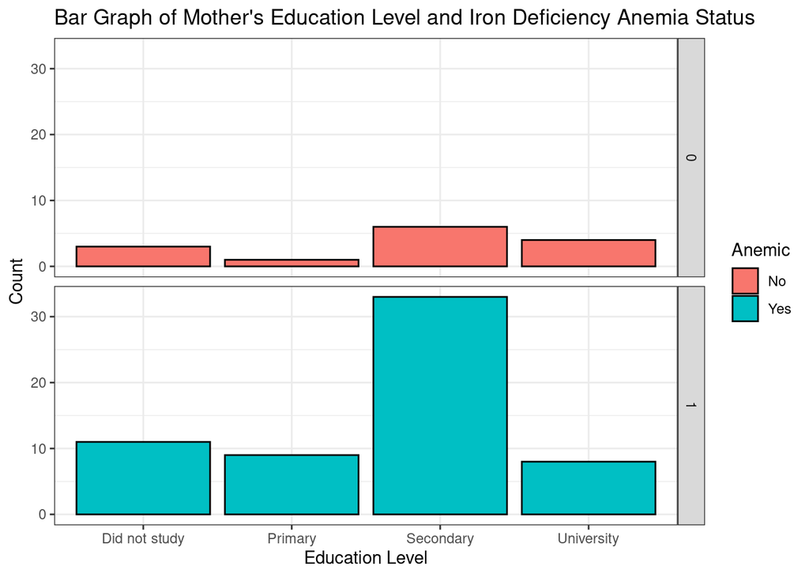

```r
ida2 %>%
  mutate(motheredu = str_to_sentence(motheredu)) %>%
  ggplot(aes(x = motheredu, fill = hb.bin))+
  geom_bar(color = "black")+
  facet_grid(hb.bin~.)+
  labs(title = "Bar Graph of Mother's Education Level and Iron Deficiency Anemia Status")+
  scale_fill_discrete(name = "Anemic", labels = c("No", "Yes"))+
  ylab("Count")+
  xlab("Education Level")+
  theme_bw()
```

### Research Question 2 Logistic Regression

```r
fit2 <- glm(factor(hb.bin) ~ factor(motheredu) + factor(sex) + childagemo, family = binomial, data = ida2)

summary(fit2)
```

```
##
## Call:
## glm(formula = factor(hb.bin) ~ factor(motheredu) + factor(sex) +
##     childagemo, family = binomial, data = ida2)
##
## Coefficients:
##                             Estimate Std. Error z value Pr(>|z|)
## (Intercept)                  0.45628    1.62507   0.281    0.779
## factor(motheredu)Primary     1.02245    1.27320   0.803    0.422
## factor(motheredu)Secondary   0.56613    0.81789   0.692    0.489
## factor(motheredu)University -0.24678    0.94044  -0.262    0.793
## factor(sex)Male              0.97401    0.64313   1.514    0.130
## childagemo                   0.01215    0.08608   0.141    0.888
##
## (Dispersion parameter for binomial family taken to be 1)
##
##     Null deviance: 72.203  on 74  degrees of freedom
## Residual deviance: 67.418  on 69  degrees of freedom
## AIC: 79.418
##
## Number of Fisher Scoring iterations: 4
```

```r
exp(fit2$coefficients)
```

```
##                 (Intercept)    factor(motheredu)Primary
##                   1.5781896                   2.7799928
##  factor(motheredu)Secondary factor(motheredu)University
##                   1.7614347                   0.7813092
##             factor(sex)Male                  childagemo
##                   2.6485536                   1.0122224
```

### Research Question 2 Results

For maternal primary education level, the odds of the child having iron deficiency anemia are 2.78 times the odds of the child having iron deficiency anemia for mothers who did not study.

For maternal secondary education level, the odds of the child having iron deficiency anemia are 1.76 times the odds of the child having iron deficiency anemia for mothers who did not study.

For maternal university education level, the odds of the child having iron deficiency anemia are 0.78 times the odds of the child having iron deficiency anemia for mothers who did not study.

However, with an alpha of 0.05, the p-value for all variables was larger than 0.05, indicating that these results are not statistically significant. We fail to reject the null hypothesis.

## Discussion and Conclusion

There is an increasing amount of literature which suggests that there may be an association between socioeconomic factors and iron deficiency anemia status of children. Wealth index was used as a predictor variable and as a proxy for socioeconomic status to assess the iron deficiency anemia status of children in India. In the initial research, the data visualization and summary statistics indicate that there could be an association between wealth index and iron deficiency anemia status. In the box plot, the median wealth index is higher on the graph for the *not* anemic outcome than the anemic outcome. In the summary statistics table, the mean wealth index for the anemic outcome is -0.0280, with a standard deviation of 2.26. The minimum wealth index is -3.86, and the maximum wealth index is 4.83. For the *not* anemic outcome, the mean wealth index is 0.216, with a standard deviation of 2.91. The minimum is -3.63, and the maximum is 4.04. These measures of centrality and dispersion overlap for both the anemic outcome and the *not* anemic outcome, suggesting more statistical analysis would be required to determine if there is an association.

After performing a logistic regression with a binary outcome for iron deficiency anemia, and the predictor variables wealth index, sex of the child, and age of the child, we can conclude that there is not a statistically significant association between the outcome and the predictor variables. There was a 6% decrease in the odds of having iron deficiency anemia for every one unit increase in wealth index; however, the p-value was greater than 0.05. The p-values for wealth index, sex of the child (male), and age of the child were 0.643, 0.093, and 0.629, respectively. Using an alpha of 0.05, these p-values are greater, and therefore, not statistically significant.

Regarding the association between maternal educational level and iron deficiency anemia status in children, the initial exploratory data analysis yielded loose trends. The bar graph seems to show more children who have iron deficiency anemia from mothers whose highest level of education was secondary school. However, after performing a logistic regression with iron deficiency anemia status as the outcome, and mother’s education level, sex of the child, and age of the child as predictor variables, there was no significant association between a mother’s education level and the iron deficiency anemia status of a child found. For maternal primary education level, the odds of a child having iron deficiency anemia were 2.78 times the odds of a child having iron deficiency anemia for mothers who did not study. In contrast, for maternal university education level, the odds of a child having iron deficiency anemia were 0.78 times the odds of a child having iron deficiency anemia for mothers who did not study. Although there is a difference between these odds ratios, the p-values were greater than 0.05, indicating that there is not a statistically significant relationship between the mother’s education level and the iron deficiency anemia status of a child.

When comparing measure of fit for both models, model one for research question one had an AIC of 76.94, which is slightly lower than the AIC of model two for question two, 79.418. This indicated that model one was a slightly better fit than model two because the same outcome variable and samples were used. However, both models produced statistically insignificant results.

Due to the visible relationship of the wealth index and iron deficiency anemia status and the low sample count, it is possible this study is underpowered. With a larger sample size, this association might exist with statistical significance. This could also be said for the association between maternal education level and iron deficiency anemia status. Using the same dataset, Houghton and colleagues (2019) performed a logistic regression analysis with anemia as the outcome variable, and predictor variables: adjusted ferritin, body iron, sTfR, RBP, zinc, selenium, folate, vitamin B12, 25(OH)D, and ln-CRP. They found that iron status was the only statistically significant factor when controlling for sex. The authors state that the strength of association should also be carefully considered given the small sample size (Houghton et al., 2019). In addition, they did not find any sociodemographic characteristics to have a statistically significant association with hemoglobin levels.

In conclusion, wealth index and mother’s education level are *not* good predictor variables of a child’s iron deficiency anemia status, and there was no association found between either variables. Although inadequate dietary iron intake and low socioeconomic status have been linked to iron deficiency anemia in other studies (Pasricha et al., 2010), these logistic regression models did not find an association. Future research should include collecting more data to increase the sample size, and allow for a higher statistically powered study.

## References

Aspuru, K., Villa, C., Bermejo, F., Herrero, P., & López, S. G. (2011). Optimal management of iron deficiency anemia due to poor dietary intake. *International journal of general medicine, 4*, 741–750. https://doi.org/10.2147/IJGM.S17788

Chandran, V., & Kirby, R. S. (2021). An Analysis of Maternal, Social and Household Factors Associated with Childhood Anemia. *International journal of environmental research and public health, 18*(6), 3105. https://doi.org/10.3390/ijerph18063105

Denic, S. and Agarwal, M.M. (2007). Nutritional iron deficiency: an evolutionary perspective. *Nutrition, 23*(7-8), 603-614. https://doi.org/10.1016/j.nut.2007.05.002.

Ekiz, C., Agaoglu, L., Karakas, Z., Gurel, N., & Yalcin, I. (2005). The effect of iron deficiency anemia on the function of the immune system. The hematology journal : the official journal of the European Haematology Association, 5(7), 579–583. https://doi.org/10.1038/sj.thj.6200574

Houghton LA, Trilok-Kumar G, McIntosh D, Haszard JJ, Harper MJ, et al. (2019) Multiple micronutrient status and predictors of anemia in young children aged 12-23 months living in New Delhi, India. *PLOS ONE 14*(2): e0209564. https://doi.org/10.1371/journal.pone.0209564

Institute of Medicine (US) Committee on the Prevention, Detection, and Management of Iron Deficiency Anemia Among U.S. Children and Women of Childbearing Age, Earl, R., & Woteki, C. E. (Eds.). (1993). *Iron Deficiency Anemia: Recommended Guidelines for the Prevention, Detection, and Management Among U.S. Children and Women of Childbearing Age.* National Academies Press (US).

Kundrapu, S., & Noguez, J. (2018). Laboratory Assessment of Anemia. *Advances in clinical chemistry, 83*, 197–225. https://doi.org/10.1016/bs.acc.2017.10.006

Lozoff B. (2007). Iron deficiency and child development. *Food and nutrition bulletin, 28*(4 Suppl), S560–S571. https://doi.org/10.1177/15648265070284S409

McIntosh, Deborah et al. (2019), Data from: Multiple micronutrient status and predictors of anemia in young children aged 12-23 months living in New Delhi, India, Dryad, Dataset, https://doi.org/10.5061/dryad.3dn67gk

Onyeneho, N.G., Ozumba, B.C. & Subramanian, S.V. (2019). Determinants of Childhood Anemia in India. *Sci Rep 9*, 16540. https://doi.org/10.1038/s41598-019-52793-3

Pasricha, S. R., Black, J., Muthayya, S., Shet, A., Bhat, V., Nagaraj, S., Prashanth, N. S., Sudarshan, H., Biggs, B. A., & Shet, A. S. (2010). Determinants of anemia among young children in rural India. *Pediatrics, 126*(1), e140–e149. https://doi.org/10.1542/peds.2009-3108

Rempel, J., Grover, K., & El-Matary, W. (2021). Micronutrient Deficiencies and Anemia in Children with Inflammatory Bowel Disease. Nutrients, 13(1), 236. https://doi.org/10.3390/nu13010236

Shimanda, P. P., Amukugo, H. J., & Norström, F. (2020). Socioeconomic factors associated with anemia among children aged 6-59 months in Namibia. *Journal of public health in Africa, 11*(1), 1131. https://doi.org/10.4081/jphia.2020.1131

Thurnham, D. I. (2014). Deficiencies of critical micronutrients: A Focus On Iodine, Iron and Vitamin A. *Sight and Life, 28*,34–45

UpToDate, Inc. (Ed.). (2023). Normal values for hematologic parameters in children. UpToDate. Retrieved April 12, 2023, from https://www.uptodate.com/contents/image?imageKey=PEDS%2F101544

Wander, K., Shell-Duncan, B., Brindle, E. (2017). Lower incidence of respiratory infections among iron-deficient children in Kilimanjaro, Tanzania, *Evolution, Medicine, and Public Health, 2017*(1), 109–119, https://doi.org/10.1093/emph/eox010

Wang, W., Knovich, M. A., Coffman, L. G., Torti, F. M., & Torti, S. V. (2010). Serum ferritin: Past, present and future. *Biochimica et biophysica acta, 1800*(8), 760–769. https://doi.org/10.1016/j.bbagen.2010.03.011

World Health Organization (WHO) (2017). Department of Nutrition for Health and Development. *Nutritional anemias: tools for effective prevention and control*. ISBN: 9789241513067

Yang, F., Liu, X., & Zha, P. (2018). Trends in Socioeconomic Inequalities and Prevalence of Anemia Among Children and Nonpregnant Women in Low- and Middle-Income Countries. *JAMA network open, 1*(5), e182899. https://doi.org/10.1001/jamanetworkopen.2018.2899